# Dr. Mehrkam SP20

# 25 February 2020

## Loading in SD Data

```r
Kobe.Ian = read_excel('Play Exp 1 (SD) Data.xlsx', sheet = 'P1_Kobe&Ian')
Sally.Vanya = read_excel('Play Exp 1 (SD) Data.xlsx', sheet = 'P2_Sally&Vanya')
Rocky.Oaky = read_excel('Play Exp 1 (SD) Data.xlsx', sheet = 'P3_Rocky&Oaky')
Rosie.Carlie = read_excel('Play Exp 1 (SD) Data.xlsx', sheet = 'P4_Rosie&Carlie')
Koda.Ava = read_excel('Play Exp 1 (SD) Data.xlsx', sheet = 'P5_Koda&Ava')
Kodi.Kaia = read_excel('Play Exp 1 (SD) Data.xlsx', sheet = 'P6_Kodi & Kaia')
Dax.Fiona = read_excel('Play Exp 1 (SD) Data.xlsx', sheet = 'P7_Dax & Fiona')
Mason.Coffee = read_excel('Play Exp 1 (SD) Data.xlsx', sheet = 'P8_Mason&Coffee')
Gunner.Cato = read_excel('Play Exp 1 (SD) Data.xlsx', sheet = 'P9_Gunner&Cato')
Misha.Houston = read_excel('Play Exp 1 (SD) Data.xlsx', sheet = 'P10_Misha&Houston')
Rev.Blitz = read_excel('Play Exp 1 (SD) Data.xlsx', sheet = 'P11_Rev&Blitz')
Jude.Luna = read_excel('Play Exp 1 (SD) Data.xlsx', sheet = 'P12_Jude&Luna')
```

## Descriptives for the SD Data

### Dax & Fiona

```r
#library(mosaic)
favstats(~Dax.Fiona$`SD (s)`)
```

|  | min | Q1 | median | Q3 | max | mean | sd | n | missing |
| --- | --- | --- | --- | --- | --- | --- | --- | --- | --- |
|  | 0 | 51.25 | 125 | 147.5 | 225 | 107 | 68.64563 | 10 | 0 |

```r
favstats(~Dax.Fiona$`S-Delta (s)`)
```

|  | min | Q1 | median | Q3 | max | mean | sd | n | missing |
| --- | --- | --- | --- | --- | --- | --- | --- | --- | --- |
|  | 0 | 0 | 0 | 0 | 145 | 21.5 | 48.65125 | 10 | 0 |

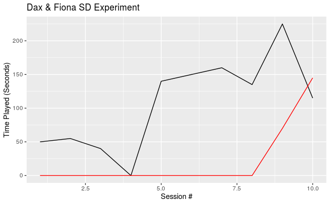

```r
gf_line(Dax.Fiona$`SD (s)`~Dax.Fiona$Session...13) %>% gf_line(Dax.Fiona$`S-Delta (s)`~Dax.Fiona$Session...13, col = 'red') %>% gf_labs(title = 'Dax & Fiona SD Experiment', x = 'Session #', y = 'Time Played (Seconds)')
```

It appears that Dax & Fiona exhibited more playing time on average when there was owner attention involved than when there was no owner attention. The SD data has a mean of 107 and a stdev of 68.64 which is large. The S-Delta data has a mean of 21.5 and a stdev of 48.65 which is also high.

### Mason & Coffee

```r
favstats(~Mason.Coffee$`SD (Attention)`)
```

|  | min | Q1 | median | Q3 | max | mean | sd | n | missing |
| --- | --- | --- | --- | --- | --- | --- | --- | --- | --- |
|  | 6 | 23.75 | 41.5 | 61.75 | 87 | 42.7 | 26.62518 | 10 | 0 |

```r
favstats(~Mason.Coffee$`S-Delta (No Attention)`)
```

|  | min | Q1 | median | Q3 | max | mean | sd | n | missing |
| --- | --- | --- | --- | --- | --- | --- | --- | --- | --- |
|  | 0 | 0 | 0 | 0 | 88 | 10.1 | 27.6745 | 10 | 0 |

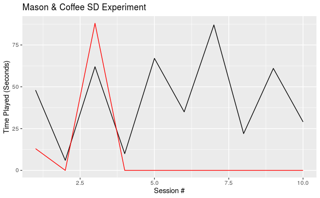

```r
gf_line(Mason.Coffee$`SD (Attention)`~Mason.Coffee$Session) %>% gf_line(Mason.Coffee$`S-Delta (No Attention)`~ Mason.Coffee$Session, col = 'red') %>% gf_labs(title = 'Mason & Coffee SD Experiment', x = 'Session #', y = 'Time Played (Seconds)')
```

It appears that Coffee and Mason played the same amount with or without attention for the first few sessions. As the sessions went on though, the continued to play with owner attention and stopped playing without owner attention. The SD data has a mean of 42.7 with a stdev of 26.62, and the S-Delta dataset has a mean of 10.1 and a stdev of 27.6. Variation is less in coffee and mason than in Dax and Fiona.

### Gunner & Cato

```r
favstats(~Gunner.Cato$`SD (Attention)`)
```

|  | min | Q1 | median | Q3 | max | mean | sd | n | missing |
| --- | --- | --- | --- | --- | --- | --- | --- | --- | --- |
|  | 0 | 131.5 | 170 | 187.5 | 232 | 154.3 | 68.01152 | 10 | 0 |

```r
favstats(~Gunner.Cato$`S-Delta (No Attention)`)
```

|  | min | Q1 | median | Q3 | max | mean | sd | n | missing |
| --- | --- | --- | --- | --- | --- | --- | --- | --- | --- |
|  | 0 | 0 | 2.5 | 90.25 | 158 | 42.1 | 59.49314 | 10 | 0 |

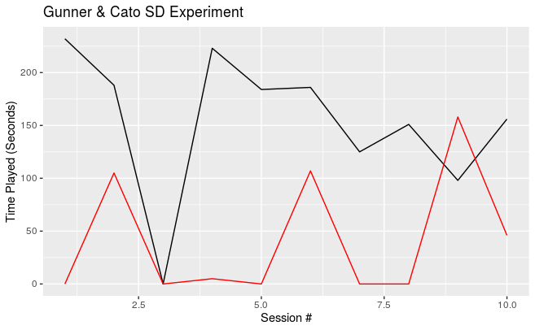

```r
gf_line(Gunner.Cato$`SD (Attention)`~ Gunner.Cato$Session) %>% gf_line(Gunner.Cato$`S-Delta (No Attention)`~ Gunner.Cato$Session, color = 'red') %>% gf_labs(title = 'Gunner & Cato SD Experiment', x = 'Session #', y = 'Time Played (Seconds)')
```

Both the SD and S-Delta trends seem to go all over the place throughout the 10 sessions, but on average it appears that Gunner and Cato play more with owner attention than without owner attention. The SD data has an average of 154.3 and a stdev of 68.012

### Misha & Houston

```r
favstats(~Misha.Houston$`SD (Attention)...3`)
```

|  | min | Q1 | median | Q3 | max | mean | sd | n | missing |
| --- | --- | --- | --- | --- | --- | --- | --- | --- | --- |
|  | 125 | 149 | 181 | 220.5 | 285 | 189 | 53.2228 | 10 | 0 |

```r
favstats(~Misha.Houston$`S-Delta (No Attention)...4`)
```

|  | min | Q1 | median | Q3 | max | mean | sd | n | missing |
| --- | --- | --- | --- | --- | --- | --- | --- | --- | --- |
|  | 0 | 0 | 0 | 0 | 170 | 17.5 | 53.60607 | 10 | 0 |

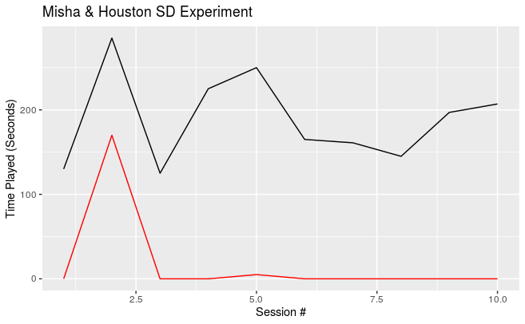

```r
gf_line(Misha.Houston$`SD (Attention)...3`~ Misha.Houston$Session...2) %>% gf_line(Misha.Houston$`S-Delta (No Attention)...4`~Misha.Houston$Session...2, color = 'red') %>% gf_labs(title = 'Misha & Houston SD Experiment', x = 'Session #', y = 'Time Played (Seconds)')
```

The SD and S-Delta trends follow a similar pattern throughout the 10 sessions, but the SD data shows more playtime throughout the sessions. The mean SD time was 189 and a stdev of 53.223 and the S-delta time has a mean of 17.5 and a stdev of 53.607.

### Rev & Blitz

```r
favstats(~Rev.Blitz$`SD (Attention)`)
```

|  | min | Q1 | median | Q3 | max | mean | sd | n | missing |
| --- | --- | --- | --- | --- | --- | --- | --- | --- | --- |
|  | 18 | 34.75 | 87 | 125.5 | 156 | 84 | 51.95511 | 10 | 0 |

```r
favstats(~Rev.Blitz$`S-Delta (No Attention)`)
```

|  | min | Q1 | median | Q3 | max | mean | sd | n | missing |
| --- | --- | --- | --- | --- | --- | --- | --- | --- | --- |
|  | 0 | 0 | 0 | 0 | 96 | 9.6 | 30.35787 | 10 | 0 |

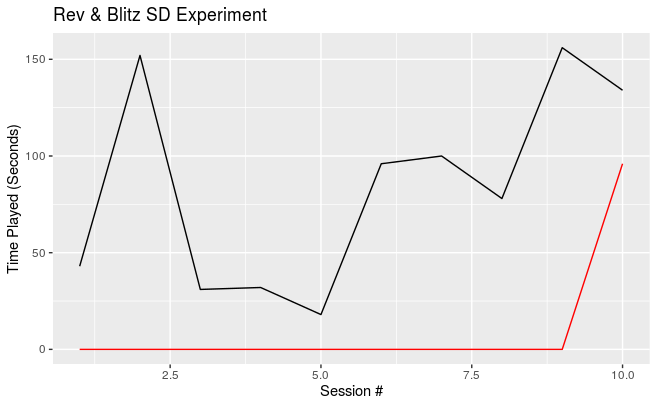

```r
gf_line(Rev.Blitz$`SD (Attention)`~ Rev.Blitz$Session) %>% gf_line(Rev.Blitz$`S-Delta (No Attention)`~ Rev.Blitz$Session, color = 'red') %>% gf_labs(title = 'Rev & Blitz SD Experiment', x = 'Session #', y = 'Time Played (Seconds)')
```

### Jude & Luna

```r
favstats(~Jude.Luna$`SD (Attention)`)
```

|  | min | Q1 | median | Q3 | max | mean | sd | n | missing |
| --- | --- | --- | --- | --- | --- | --- | --- | --- | --- |
|  | 0 | 0 | 12.5 | 115.75 | 172 | 52.2 | 73.27998 | 10 | 0 |

```r
favstats(~Jude.Luna$`S-Delta (No Attention)`)
```

|  | min | Q1 | median | Q3 | max | mean | sd | n | missing |
| --- | --- | --- | --- | --- | --- | --- | --- | --- | --- |
|  | 0 | 0 | 0 | 5.5 | 10 | 2.9 | 4.067486 | 10 | 0 |

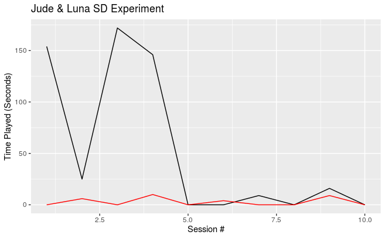

```r
gf_line(Jude.Luna$`SD (Attention)`~Jude.Luna$Session) %>% gf_line(Jude.Luna$`S-Delta (No Attention)`~Jude.Luna$Session, color = 'red') %>% gf_labs(title = 'Jude & Luna SD Experiment', x = 'Session #', y = 'Time Played (Seconds)')
```

# 27 February 2020

## Loading in EO Data

```r
Dax.Fiona.E0 = read_excel('Play Exp 2 (EO) Data.xlsx', sheet = 'P7_Dax & Fiona')
Misha.Houston.EO = read_excel('Play Exp 2 (EO) Data.xlsx', sheet = 'P8_Misha&Houston')
Gunner.Cato.EO = read_excel('Play Exp 2 (EO) Data.xlsx', sheet = 'P9_Gunner&Cato')
Coffee.Mason.EO = read_excel('Play Exp 2 (EO) Data.xlsx', sheet = 'P10_Coffee&Mason')
Rev.Blitz.EO = read_excel('Play Exp 2 (EO) Data.xlsx', sheet = 'P11_Rev&Blitz')
```

## Loading in Reinforced Data

```r
Dax.Fiona.Rein = read_excel('Play Exp 3 (Reinforcer) Data Edited.xlsx', sheet = 'P7_Dax & Fiona')
```

```
* `` -> ...6
```

```r
Misha.Houston.Rein = read_excel('Play Exp 3 (Reinforcer) Data Edited.xlsx', sheet = 'P8_Misha&Houston')
```

```
* `` -> ...6
```

```r
Gunner.Cato.Rein = read_excel('Play Exp 3 (Reinforcer) Data Edited.xlsx', sheet = 'P9_Gunner&Cato')
```

```
* `` -> ...6
```

```r
Coffee.Mason.Rein = read_excel('Play Exp 3 (Reinforcer) Data Edited.xlsx', sheet = 'P10_Coffee&Mason')
```

```
* Date -> Date...1
* `` -> ...6
* `` -> ...11
* `` -> ...12
* `` -> ...13
* … and 17 more problems
```

```r
Rev.Blitz.Rein = read_excel('Play Exp 3 (Reinforcer) Data Edited.xlsx', sheet = 'P11_Rev&Blitz')
```

```
* `` -> ...6
```

## Descriptives for Reinforced Data

### Dax & Fiona

```r
favstats(Dax.Fiona.Rein$`Attention Control`)
```

|  | min | Q1 | median | Q3 | max | mean | sd | n | missing |
| --- | --- | --- | --- | --- | --- | --- | --- | --- | --- |
|  | 128 | 173.25 | 215.5 | 233.75 | 267 | 204.1667 | 51.00359 | 6 | 3 |

```r
favstats(Dax.Fiona.Rein$`Attention Test`)
```

|  | min | Q1 | median | Q3 | max | mean | sd | n | missing |
| --- | --- | --- | --- | --- | --- | --- | --- | --- | --- |
|  | 0 | 29.75 | 106 | 121.5 | 137 | 80 | 60.45825 | 6 | 3 |

```r
favstats(Dax.Fiona.Rein$Alone)
```

|  | min | Q1 | median | Q3 | max | mean | sd | n | missing |
| --- | --- | --- | --- | --- | --- | --- | --- | --- | --- |
|  | 0 | 13.25 | 114 | 180.25 | 224 | 105.6667 | 99.741 | 6 | 3 |

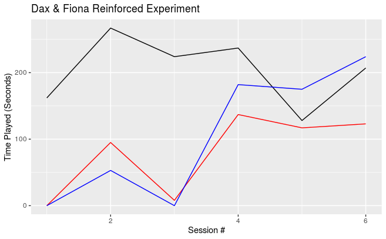

```r
gf_line(Dax.Fiona.Rein$`Attention Control`~Dax.Fiona.Rein$Session) %>% gf_line(Dax.Fiona.Rein$`Attention Test`~ Dax.Fiona.Rein$Session, color = 'red') %>% gf_line(Dax.Fiona.Rein$Alone~Dax.Fiona.Rein$Session, color = 'blue') %>% gf_labs(title = 'Dax & Fiona Reinforced Experiment', x = 'Session #', y = 'Time Played (Seconds)')
```

# 3 March 2020

### Misha & Houston

```r
favstats(~Misha.Houston.Rein$`Attention Control`)
```

|  | min | Q1 | median | Q3 | max | mean | sd | n | missing |
| --- | --- | --- | --- | --- | --- | --- | --- | --- | --- |
|  | 0 | 0.65 | 59.8 | 130.875 | 152 | 67.85 | 74.21358 | 6 | 0 |

```r
favstats(~Misha.Houston.Rein$`Attention Test`)
```

|  | min | Q1 | median | Q3 | max | mean | sd | n | missing |
| --- | --- | --- | --- | --- | --- | --- | --- | --- | --- |
|  | 0 | 0 | 0 | 40.5 | 82.5 | 22.75 | 36.37822 | 6 | 0 |

```r
favstats(~Misha.Houston.Rein$Alone)
```

|  | min | Q1 | median | Q3 | max | mean | sd | n | missing |
| --- | --- | --- | --- | --- | --- | --- | --- | --- | --- |
|  | 0 | 0 | 0 | 79.5 | 130.5 | 39.41667 | 61.55357 | 6 | 0 |

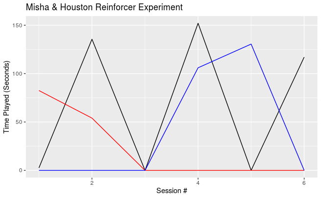

```r
gf_line(Misha.Houston.Rein$`Attention Control`~Misha.Houston.Rein$Session) %>% gf_line(Misha.Houston.Rein$`Attention Test`~Misha.Houston.Rein$Session, color = 'red') %>% gf_line(Misha.Houston.Rein$Alone~Misha.Houston.Rein$Session, color = 'blue') %>% gf_labs(title = 'Misha & Houston Reinforcer Experiment', x = 'Session #', y = 'Time Played (Seconds)')
```

### Gunner & Cato

```r
favstats(~Gunner.Cato.Rein$`Attention Control`)
```

|  | min | Q1 | median | Q3 | max | mean | sd | n | missing |
| --- | --- | --- | --- | --- | --- | --- | --- | --- | --- |
|  | 0 | 79.5 | 159 | 214.75 | 223 | 135.25 | 104.4649 | 4 | 2 |

```r
favstats(~Gunner.Cato.Rein$`Attention Test`)
```

|  | min | Q1 | median | Q3 | max | mean | sd | n | missing |
| --- | --- | --- | --- | --- | --- | --- | --- | --- | --- |
|  | 0 | 0 | 0 | 2.25 | 9 | 2.25 | 4.5 | 4 | 2 |

```r
favstats(~Gunner.Cato.Rein$Alone)
```

|  | min | Q1 | median | Q3 | max | mean | sd | n | missing |
| --- | --- | --- | --- | --- | --- | --- | --- | --- | --- |
|  | 0 | 0 | 8 | 54 | 168 | 46 | 81.68231 | 4 | 2 |

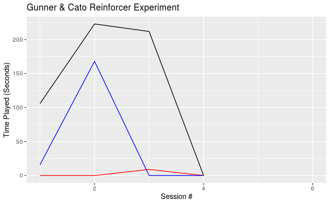

```r
gf_line(Gunner.Cato.Rein$`Attention Control`~Gunner.Cato.Rein$Session) %>% gf_line(Gunner.Cato.Rein$`Attention Test`~Gunner.Cato.Rein$Session, color = 'red') %>% gf_line(Gunner.Cato.Rein$Alone~Gunner.Cato.Rein$Session, color = 'blue') %>% gf_labs(title = 'Gunner & Cato Reinforcer Experiment', x = 'Session #', y = 'Time Played (Seconds)')
```

### Coffee & Mason

```r
favstats(~Coffee.Mason.Rein$`Attention Control`)
```

|  | min | Q1 | median | Q3 | max | mean | sd | n | missing |
| --- | --- | --- | --- | --- | --- | --- | --- | --- | --- |
|  | 3 | 4.75 | 18.5 | 78 | 113 | 41.83333 | 49.15045 | 6 | 3 |

```r
favstats(~Coffee.Mason.Rein$`Attention Test`)
```

|  | min | Q1 | median | Q3 | max | mean | sd | n | missing |
| --- | --- | --- | --- | --- | --- | --- | --- | --- | --- |
|  | 0 | 0 | 0 | 0 | 43 | 7.166667 | 17.55468 | 6 | 3 |

```r
favstats(~Coffee.Mason.Rein$Alone)
```

|  | min | Q1 | median | Q3 | max | mean | sd | n | missing |
| --- | --- | --- | --- | --- | --- | --- | --- | --- | --- |
|  | 0 | 0 | 0 | 0 | 0 | 0 | 0 | 6 | 3 |

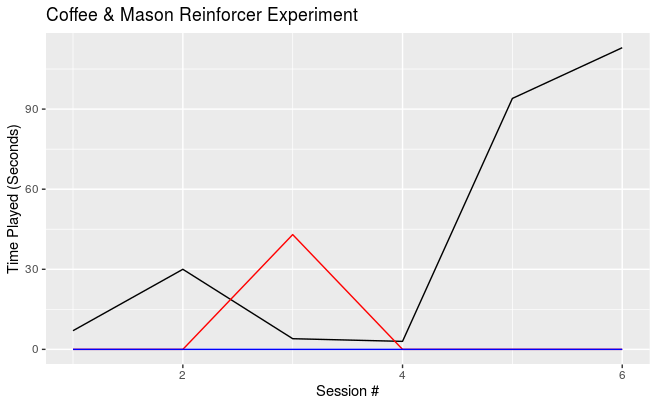

```r
gf_line(Coffee.Mason.Rein$`Attention Control`~Coffee.Mason.Rein$Session) %>% gf_line(Coffee.Mason.Rein$`Attention Test`~Coffee.Mason.Rein$Session, color = 'red') %>% gf_line(Coffee.Mason.Rein$Alone~Coffee.Mason.Rein$Session, color = 'blue') %>% gf_labs(title = 'Coffee & Mason Reinforcer Experiment', x = 'Session #', y = 'Time Played (Seconds)')
```

### Rev & Blitz

```r
favstats(~Rev.Blitz.Rein$`Attention Control`)
```

|  | min | Q1 | median | Q3 | max | mean | sd | n | missing |
| --- | --- | --- | --- | --- | --- | --- | --- | --- | --- |
|  | 0 | 8.25 | 37.5 | 62.25 | 81 | 37.5 | 33.8275 | 6 | 0 |

```r
favstats(~Rev.Blitz.Rein$`Attention Test`)
```

|  | min | Q1 | median | Q3 | max | mean | sd | n | missing |
| --- | --- | --- | --- | --- | --- | --- | --- | --- | --- |
|  | 0 | 4.25 | 11.5 | 23.25 | 27 | 13.16667 | 11.6519 | 6 | 0 |

```r
favstats(~Rev.Blitz.Rein$Alone)
```

|  | min | Q1 | median | Q3 | max | mean | sd | n | missing |
| --- | --- | --- | --- | --- | --- | --- | --- | --- | --- |
|  | 0 | 0 | 0 | 26.25 | 37 | 12 | 18.60108 | 6 | 0 |

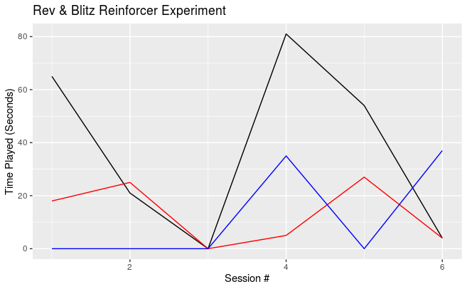

```r
gf_line(Rev.Blitz.Rein$`Attention Control`~Rev.Blitz.Rein$Session) %>% gf_line(Rev.Blitz.Rein$`Attention Test`~Rev.Blitz.Rein$Session, color = 'red') %>% gf_line(Rev.Blitz.Rein$Alone~Rev.Blitz.Rein$Session, color = 'blue') %>% gf_labs(title = 'Rev & Blitz Reinforcer Experiment', x = 'Session #', y = 'Time Played (Seconds)')
```

## Descriptives for EO Dataset

### Dax & Fiona

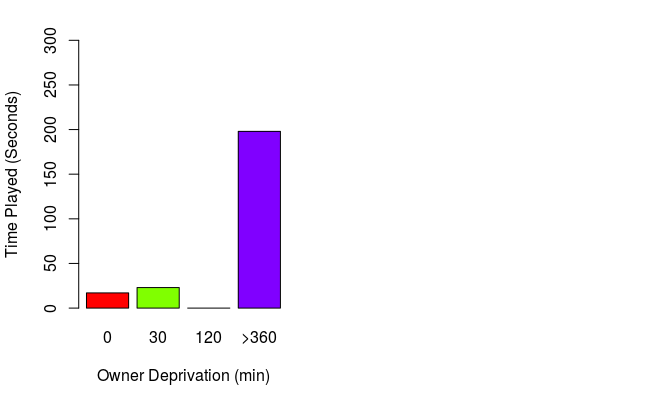

```r
par(mfrow = c(1,2))
barplot(c(17,23,    0,  198), names.arg = c('0', '30', '120', '>360'), ylim = c(0,300), xlab = 'Owner Deprivation (min)', ylab = 'Time Played (Seconds)',col = rainbow(4))
barplot(c(0 ,4  ,0  ,192), names.arg = c('0', '30', '120', '>360'), ylim = c(0,300), xlab = 'Owner Deprivation (min)', ylab = 'Time Played (Seconds)',col = rainbow(4))
```

### Misha & Houston

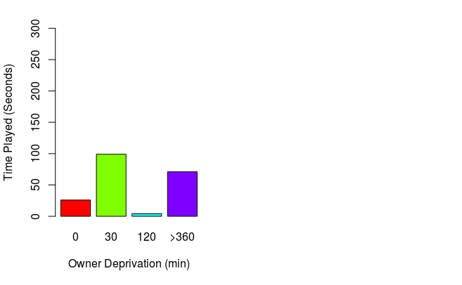

```r
par(mfrow = c(1,2))
barplot(c(26,   99, 4,  71), names.arg = c('0', '30', '120', '>360'), ylim = c(0,300), xlab = 'Owner Deprivation (min)', ylab = 'Time Played (Seconds)',col = rainbow(4))
barplot(c(3,    0,  9,  92), names.arg = c('0', '30', '120', '>360'), ylim = c(0,300), xlab = 'Owner Deprivation (min)', ylab = 'Time Played (Seconds)',col = rainbow(4))
```

### Gunner & Cato

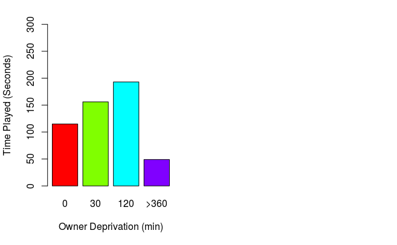

```r
par(mfrow = c(1,2))
barplot(c(115   ,156    ,193,   49), names.arg = c('0', '30', '120', '>360'), ylim = c(0,300), xlab = 'Owner Deprivation (min)', ylab = 'Time Played (Seconds)',col = rainbow(4))
barplot(c(4 ,106,   119,    203), names.arg = c('0', '30', '120', '>360'), ylim = c(0,300), xlab = 'Owner Deprivation (min)', ylab = 'Time Played (Seconds)',col = rainbow(4))
```

### Coffee & Mason

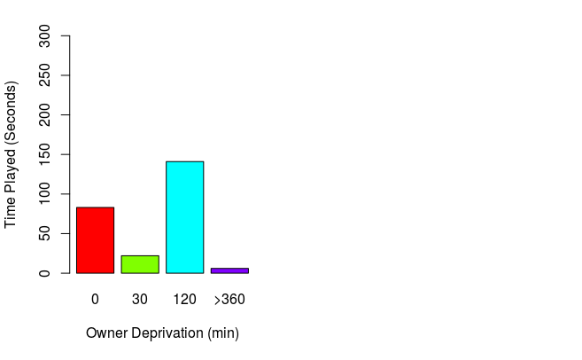

```r
par(mfrow = c(1,2))
barplot(c(83    ,22,    141 ,6), names.arg = c('0', '30', '120', '>360'), ylim = c(0,300), xlab = 'Owner Deprivation (min)', ylab = 'Time Played (Seconds)',col = rainbow(4))
barplot(c(12,   2   ,0  ,1), names.arg = c('0', '30', '120', '>360'), ylim = c(0,300), xlab = 'Owner Deprivation (min)', ylab = 'Time Played (Seconds)',col = rainbow(4))
```

### Rev & Blitz

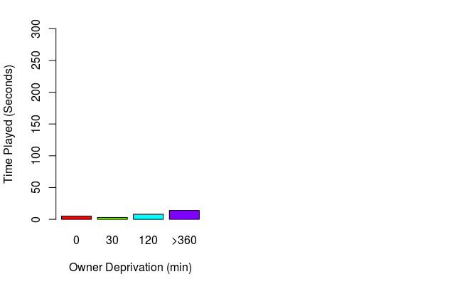

```r
par(mfrow = c(1,2))
barplot(c(5 ,3  ,8  ,14), names.arg = c('0', '30', '120', '>360'), ylim = c(0,300), xlab = 'Owner Deprivation (min)', ylab = 'Time Played (Seconds)',col = rainbow(4))
barplot(c(1 ,1  ,1  ,14), names.arg = c('0', '30', '120', '>360'), ylim = c(0,300), xlab = 'Owner Deprivation (min)', ylab = 'Time Played (Seconds)',col = rainbow(4))
```

# 4 March 2020

## Wilcox tests for SD Data

### Dax and Fiona

```r
wilcox.test(Dax.Fiona$`SD (s)`, Dax.Fiona$`S-Delta (s)`, alternative = c('two.sided'))
```

```
cannot compute exact p-value with ties
```

```
    Wilcoxon rank sum test with continuity correction

data:  Dax.Fiona$`SD (s)` and Dax.Fiona$`S-Delta (s)`
W = 85, p-value = 0.006253
alternative hypothesis: true location shift is not equal to 0
```

The Mann Whitney U test shows a p-value of 0.0063, which is significant enough in terms of the exact alpha value to reject the null hypothesis. We can conclude that the distributions of the SD and S-delta are different for Dax and Fiona.

# 24 March 2020

### Misha & Houston

```r
wilcox.test(Misha.Houston$`SD (Attention)...22`, Misha.Houston$`S-Delta (No Attention)...23`, alternative = 'two.sided')
```

```
cannot compute exact p-value with ties
```

```
    Wilcoxon rank sum test with continuity correction

data:  Misha.Houston$`SD (Attention)...22` and Misha.Houston$`S-Delta (No Attention)...23`
W = 88, p-value = 0.003404
alternative hypothesis: true location shift is not equal to 0
```

The Mann Whitney U test shows a p-value of 0.0034, which is significant enough in terms of the exact alpha value to reject the null hypothesis. We can conclude that the distributions of the SD and S-delta are different for Misha and Houston

### Gunner & Cato

```r
wilcox.test(Gunner.Cato$`SD (Attention)`, Gunner.Cato$`S-Delta (No Attention)`, alternative = 'two.sided')
```

```
cannot compute exact p-value with ties
```

```
    Wilcoxon rank sum test with continuity correction

data:  Gunner.Cato$`SD (Attention)` and Gunner.Cato$`S-Delta (No Attention)`
W = 86.5, p-value = 0.005818
alternative hypothesis: true location shift is not equal to 0
```

The Mann Whitney U test shows a p-value of 0.0058, which is significant enough in terms of the exact alpha value to reject the null hypothesis. We can conclude that the distributions of the SD and S-delta are different for Gunner & Cato

### Coffee & Mason

```r
wilcox.test(Mason.Coffee$`SD (Attention)`, Mason.Coffee$`S-Delta (No Attention)`, alternative = 'two.sided')
```

```
cannot compute exact p-value with ties
```

```
    Wilcoxon rank sum test with continuity correction

data:  Mason.Coffee$`SD (Attention)` and Mason.Coffee$`S-Delta (No Attention)`
W = 88, p-value = 0.003404
alternative hypothesis: true location shift is not equal to 0
```

The Mann Whitney U test shows a p-value of 0.0034, which is significant enough in terms of the exact alpha value to reject the null hypothesis. We can conclude that the distributions of the SD and S-delta are different for Mason and Coffee.

### Rev & Blitz

```r
wilcox.test(Rev.Blitz$`SD (Attention)`, Rev.Blitz$`S-Delta (No Attention)`, alternative = 'two.sided')
```

```
cannot compute exact p-value with ties
```

```
    Wilcoxon rank sum test with continuity correction

data:  Rev.Blitz$`SD (Attention)` and Rev.Blitz$`S-Delta (No Attention)`
W = 94.5, p-value = 0.0004856
alternative hypothesis: true location shift is not equal to 0
```

## Kruskall-Wallis Tests for Reinforced Data

### Dax & Fiona

```r
library(dunn.test)
kruskal.test(Dax.Fiona.Rein$`Attention Control`, Dax.Fiona.Rein$`Attention Test`, Dax.Fiona.Rein$Alone)
```

```
    Kruskal-Wallis rank sum test

data:  Dax.Fiona.Rein$`Attention Control` and Dax.Fiona.Rein$`Attention Test`
Kruskal-Wallis chi-squared = 5, df = 5, p-value = 0.4159
```

```r
dunn.test(c(Dax.Fiona.Rein$`Attention Control`[1:6], Dax.Fiona.Rein$`Attention Test`[1:6], Dax.Fiona.Rein$Alone[1:6]), g = c(rep(1,6), rep(2,6), rep(3,6)))
```

```
  Kruskal-Wallis rank sum test

data: x and group
Kruskal-Wallis chi-squared = 7.1274, df = 2, p-value = 0.03

                           Comparison of x by group
                                (No adjustment)
Col Mean-|
Row Mean |          1          2
---------+----------------------
       2 |   2.575158
         |    0.0050*
       3 |   1.897485  -0.677673
         |     0.0289     0.2490

alpha = 0.05
Reject Ho if p <= alpha/2
```